# GEICO - Mini Project : Logistic Regression Models

Giovanni Fossati

# PRELIMINARIES

## Loading the data sets (previously saved)

```r
datasets_list <- c("0a", "0b", 1:5)
for( i in datasets_list ) {
    dd <- readRDS(paste0("./data/data", i, "_packed.RDS"))
    assign(paste0("data", i, ".train"), dd$train)
    assign(paste0("data", i, ".test"), dd$test)
    rm(dd)
}
```

# Logistic Regression w/ `data0a`

We fit `data0a` using R’s `glm()` function. The summary is shown below.

```r
GLM0a.train <- data0a.train
GLM0a.test <-  data0a.test

GLM0a.model <- glm(Call_Flag ~ . , data = GLM0a.train, family = "binomial")
```

```r
summary(GLM0a.model)
#
# Call:
# glm(formula = Call_Flag ~ ., family = "binomial", data = GLM0a.train)
#
# Deviance Residuals:
#     Min       1Q   Median       3Q      Max
# -2.5403  -0.2745  -0.1362  -0.0813   4.4789
#
# Coefficients:
#                        Estimate Std. Error z value Pr(>|z|)
# (Intercept)           -1.954422   0.166590 -11.732  < 2e-16 ***
# DATE_FOR5/14/2014     -0.059833   0.074398  -0.804 0.421261
# DATE_FOR5/15/2014     -0.202802   0.075313  -2.693 0.007086 **
# DATE_FOR5/16/2014     -0.147374   0.073964  -1.993 0.046315 *
# DATE_FOR5/17/2014     -0.070418   0.074580  -0.944 0.345073
# DATE_FOR5/18/2014     -0.159769   0.074771  -2.137 0.032616 *
# DATE_FOR5/19/2014     -0.340998   0.077480  -4.401 1.08e-05 ***
# DATE_FOR5/20/2014     -0.628977   0.085079  -7.393 1.44e-13 ***
# RTD_ST_CDST_01         0.017761   0.188027   0.094 0.924742
# RTD_ST_CDST_02        -0.019617   0.172318  -0.114 0.909362
# RTD_ST_CDST_03         0.032665   0.140509   0.232 0.816167
# RTD_ST_CDST_04         0.022109   0.115218   0.192 0.847828
# RTD_ST_CDST_05         0.581263   0.419498   1.386 0.165865
# RTD_ST_CDST_06         0.047032   0.126388   0.372 0.709804
# RTD_ST_CDST_07         0.124571   0.085905   1.450 0.147032
# RTD_ST_CDST_08         0.492506   0.189146   2.604 0.009218 **
# RTD_ST_CDST_09         0.070805   0.089627   0.790 0.429532
# RTD_ST_CDST_10        -0.324901   0.249249  -1.304 0.192396
# RTD_ST_CDST_11         0.013530   0.123499   0.110 0.912761
# RTD_ST_CDST_12        -0.061852   0.166589  -0.371 0.710423
# RTD_ST_CDST_13        -0.301785   0.279021  -1.082 0.279437
# RTD_ST_CDST_14         0.110940   0.108115   1.026 0.304831
# RTD_ST_CDST_15        -0.183190   0.294950  -0.621 0.534541
# RTD_ST_CDST_16        -0.452027   0.168750  -2.679 0.007391 **
# RTD_ST_CDST_17         0.053562   0.217824   0.246 0.805762
# RTD_ST_CDST_18         0.702716   0.205426   3.421 0.000624 ***
# RTD_ST_CDST_19        -0.449868   0.320634  -1.403 0.160600
# RTD_ST_CDST_20        -0.241594   0.171713  -1.407 0.159437
# RTD_ST_CDST_21         0.043161   0.202129   0.214 0.830912
# RTD_ST_CDST_22        -0.028993   0.115733  -0.251 0.802189
# RTD_ST_CDST_23         0.028787   0.346259   0.083 0.933742
# RTD_ST_CDST_24         0.142488   0.188992   0.754 0.450888
# RTD_ST_CDST_25         0.060357   0.152618   0.395 0.692491
# RTD_ST_CDST_26        -0.247248   0.429528  -0.576 0.564867
# RTD_ST_CDST_27        -0.164072   0.343990  -0.477 0.633384
# RTD_ST_CDST_28        -0.005104   0.248583  -0.021 0.983618
# RTD_ST_CDST_29        -0.423662   0.402415  -1.053 0.292433
# RTD_ST_CDST_30        -0.681201   0.524002  -1.300 0.193602
# RTD_ST_CDST_31        -0.515100   0.398000  -1.294 0.195590
# RTD_ST_CDST_32         0.120249   0.165872   0.725 0.468485
# RTD_ST_CDST_33         0.040912   0.152881   0.268 0.789000
# RTD_ST_CDST_34        -0.499940   0.380471  -1.314 0.188845
# RTD_ST_CDST_35        -0.400005   0.368393  -1.086 0.277562
# RTD_ST_CDST_36         0.078857   0.294537   0.268 0.788906
# RTD_ST_CDST_37         0.261433   0.323301   0.809 0.418725
# RTD_ST_CDST_38        -0.480396   0.215733  -2.227 0.025960 *
# RTD_ST_CDST_39        -0.200467   0.200889  -0.998 0.318329
# RTD_ST_CDST_40        -0.026905   0.272726  -0.099 0.921415
# RTD_ST_CDST_41         0.173927   0.239681   0.726 0.468049
# RTD_ST_CDST_42        -0.025328   0.121543  -0.208 0.834924
# RTD_ST_CDST_43        -0.283680   0.404562  -0.701 0.483176
# RTD_ST_CDST_44         0.094329   0.212882   0.443 0.657689
# RTD_ST_CDST_45        -1.135797   0.600860  -1.890 0.058720 .
# RTD_ST_CDST_46         0.173889   0.682059   0.255 0.798763
# RTD_ST_CDST_47         0.125468   0.490072   0.256 0.797936
# RTD_ST_CDST_48         0.477310   0.265925   1.795 0.072669 .
# RTD_ST_CDST_49         0.052763   0.732044   0.072 0.942541
# RTD_ST_CDST_50         0.244742   0.205893   1.189 0.234562
# CHANNEL1_6M            0.454999   0.057532   7.909 2.60e-15 ***
# CHANNEL2_6M            0.400102   0.043174   9.267  < 2e-16 ***
# CHANNEL3_6M            0.223102   0.058274   3.829 0.000129 ***
# CHANNEL4_6M            0.876756   0.041136  21.314  < 2e-16 ***
# CHANNEL5_6M           -0.060213   0.089012  -0.676 0.498753
# METHOD1_6M             0.046704   0.029388   1.589 0.112011
# PAYMENTS_6M           -0.569874   0.040160 -14.190  < 2e-16 ***
# CustomerSegment2      -0.025410   0.049208  -0.516 0.605591
# CustomerSegment3      -0.126147   0.093176  -1.354 0.175782
# CustomerSegmentNONE   -0.746372   0.128193  -5.822 5.81e-09 ***
# Tenure                -0.017251   0.003249  -5.310 1.10e-07 ***
# Age                    0.004666   0.001613   2.892 0.003827 **
# MART_STATUSMS_1       -0.044501   0.099570  -0.447 0.654925
# MART_STATUSMS_2       -0.102939   0.097368  -1.057 0.290410
# MART_STATUSMS_3       -0.107469   0.106379  -1.010 0.312377
# MART_STATUSMS_4       -0.031840   0.118310  -0.269 0.787835
# GENDERM                0.097962   0.039903   2.455 0.014088 *
# CHANNEL1_3M           -0.027741   0.104545  -0.265 0.790740
# CHANNEL2_3M           -0.142416   0.078251  -1.820 0.068760 .
# CHANNEL3_3M           -0.369697   0.109200  -3.386 0.000710 ***
# CHANNEL4_3M            0.028025   0.072860   0.385 0.700503
# CHANNEL5_3M           -0.250575   0.169597  -1.477 0.139550
# METHOD1_3M            -0.094723   0.055462  -1.708 0.087658 .
# PAYMENTS_3M            0.038159   0.068234   0.559 0.575994
# RECENT_PAYMENT        -1.235220   0.095463 -12.939  < 2e-16 ***
# NOT_DI_3M              0.786501   0.174274   4.513 6.39e-06 ***
# NOT_DI_6M             -0.241022   0.152819  -1.577 0.114755
# EVENT2_90_SUM         -0.261558   0.041565  -6.293 3.12e-10 ***
# LOGINS                -0.090993   0.022378  -4.066 4.78e-05 ***
# POLICYPURCHASECHANNEL -0.582666   0.077277  -7.540 4.70e-14 ***
# ---
# Signif. codes:  0 '***' 0.001 '**' 0.01 '*' 0.05 '.' 0.1 ' ' 1
#
# (Dispersion parameter for binomial family taken to be 1)
#
#     Null deviance: 28386  on 90493  degrees of freedom
# Residual deviance: 21767  on 90406  degrees of freedom
# AIC: 21943
#
# Number of Fisher Scoring iterations: 8
```

### Prediction on Test set

Setting a **threshold** on the response at **0.2**

```r
GLM0a.test.predict <- predict(GLM0a.model, type = "response", newdata = GLM0a.test)

GLM0a.test.performance <- prepare_cmat_performance(predicted = GLM0a.test.predict > GLM0a.threshold, truth = GLM0a.test$Call_Flag)
GLM0a.test.cmat <- GLM0a.test.performance$cmatrix
GLM0a.test.accuracy <- GLM0a.test.performance$accuracy

GLM0a.ROCR_pred_test <- prediction(GLM0a.test.predict, GLM0a.test$Call_Flag)
GLM0a.perf <- performance(GLM0a.ROCR_pred_test, "tpr", "fpr")
GLM0a.AUC <- as.numeric(performance(GLM0a.ROCR_pred_test, "auc")@y.values)

GLM0a.test.performance$AUC <- GLM0a.AUC
```

- With a threshold at **0.2** the *out-of-sample* confusion matrix for this fit and train/test sets is:

GLM0a Confusion Matrix (threshold = 0.2)

|  | 0 | 1 |
| --- | --- | --- |
| FALSE | 36554 | 1058 |
| TRUE | 812 | 359 |

The **Area Under the Curve** (**AUC**) for this model on the test data is **0.8515**, which means that our model can differentiate between a randomly selected *retained* and *non-retained* user about **85.15%** of the times.

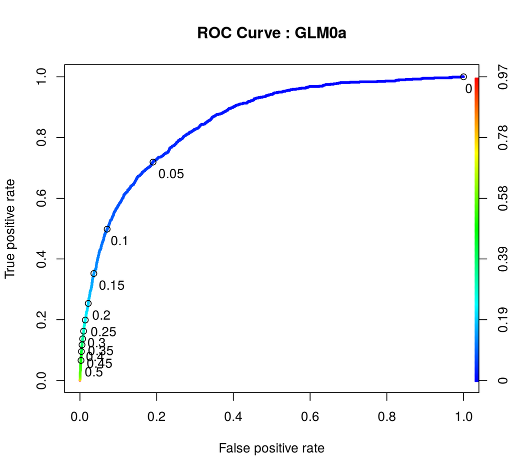

```r
# cutoffs <- seq(0.0, 1.0, by = 0.1)
cutoffs <- seq(0.0, 0.5, by = 0.05)
t.adj <- c(-0.2, 1.7)
str_title <- paste0("ROC Curve : GLM0a")
plot(GLM0a.perf, main = str_title, lwd = 3, colorize = TRUE, print.cutoffs.at = cutoffs, text.adj = t.adj)
```

```r
flag_ext <- TRUE

# perf_vs_threshold <- list()
perf_vs_threshold <- list(AUC = GLM0a.AUC)
i <- 1
for( threshold in seq(0.05, 0.4, by = 0.05)) {
    i <- i + 1
    this_model <- GLM0a.model
    this_test_data <- GLM0a.test
    this_test_predict <- predict(this_model, type = "response", newdata = this_test_data)

    perf_vs_threshold[[i]] <- prepare_cmat_performance(predicted = this_test_predict,
                                                       threshold = threshold,
                                                       truth = this_test_data$Call_Flag)
    names(perf_vs_threshold)[i] <- paste0("thr_", sprintf("%4.2f", threshold))
    if( i == 2 ) {
        perf_vs_threshold.table <- print_cmat_performance(perf_vs_threshold[[i]], errors = FALSE, extended = flag_ext, direction = "h")
    } else {
        perf_vs_threshold.table <- rbind(perf_vs_threshold.table,
                                         print_cmat_performance(perf_vs_threshold[[i]], errors = FALSE, extended = flag_ext, direction = "h"))
    }
    perf_vs_threshold[[i]]$AUC <- GLM0a.AUC
}
GLM0a.perf_vs_threshold <- perf_vs_threshold
GLM0a.perf_vs_threshold$table <- perf_vs_threshold.table
GLM0a.perf_vs_threshold$table$Threshold <- sprintf("**%.2f**", GLM0a.perf_vs_threshold$table$Threshold)
kable(GLM0a.perf_vs_threshold$table, digits = 3, align = "c", caption = "GLM0a Performance Measures vs. Threshold for Classification")
```

GLM0a Performance Measures vs. Threshold for Classification

| Threshold | Accuracy | Sensitivity | Specificity | Precision | NPV | F1 Score |
| --- | --- | --- | --- | --- | --- | --- |
| **0.05** | 0.806 | 0.719 | 0.809 | 0.125 | 0.987 | 0.213 |
| **0.10** | 0.913 | 0.498 | 0.929 | 0.210 | 0.980 | 0.296 |
| **0.15** | 0.941 | 0.352 | 0.964 | 0.269 | 0.975 | 0.305 |
| **0.20** | 0.952 | 0.253 | 0.978 | 0.307 | 0.972 | 0.277 |
| **0.25** | 0.957 | 0.198 | 0.986 | 0.350 | 0.970 | 0.253 |
| **0.30** | 0.960 | 0.162 | 0.990 | 0.392 | 0.969 | 0.230 |
| **0.35** | 0.962 | 0.137 | 0.993 | 0.425 | 0.968 | 0.207 |
| **0.40** | 0.963 | 0.117 | 0.995 | 0.450 | 0.967 | 0.186 |

# Logistic Regression w/ `data0b`

We fit `data0b` using R’s `glm()` function. The summary is shown below.

```r
GLM0b.train <- data0b.train
GLM0b.test <-  data0b.test

GLM0b.model <- glm(Call_Flag ~ . , data = GLM0b.train, family = "binomial")
```

```r
summary(GLM0b.model)
#
# Call:
# glm(formula = Call_Flag ~ ., family = "binomial", data = GLM0b.train)
#
# Deviance Residuals:
#     Min       1Q   Median       3Q      Max
# -2.5452  -0.2752  -0.1369  -0.0830   4.4972
#
# Coefficients:
#                        Estimate Std. Error z value Pr(>|z|)
# (Intercept)           -2.137721   0.158355 -13.500  < 2e-16 ***
# RTD_ST_CDST_01         0.024148   0.187539   0.129 0.897547
# RTD_ST_CDST_02        -0.027091   0.171942  -0.158 0.874804
# RTD_ST_CDST_03         0.021634   0.140441   0.154 0.877573
# RTD_ST_CDST_04         0.016818   0.115204   0.146 0.883932
# RTD_ST_CDST_05         0.599856   0.419150   1.431 0.152395
# RTD_ST_CDST_06         0.038390   0.126175   0.304 0.760932
# RTD_ST_CDST_07         0.128367   0.085810   1.496 0.134668
# RTD_ST_CDST_08         0.482807   0.188518   2.561 0.010435 *
# RTD_ST_CDST_09         0.071781   0.089510   0.802 0.422592
# RTD_ST_CDST_10        -0.327879   0.248993  -1.317 0.187899
# RTD_ST_CDST_11         0.008020   0.123300   0.065 0.948136
# RTD_ST_CDST_12        -0.061064   0.166599  -0.367 0.713967
# RTD_ST_CDST_13        -0.305415   0.278712  -1.096 0.273163
# RTD_ST_CDST_14         0.116048   0.107975   1.075 0.282476
# RTD_ST_CDST_15        -0.169054   0.293784  -0.575 0.564997
# RTD_ST_CDST_16        -0.455826   0.168532  -2.705 0.006837 **
# RTD_ST_CDST_17         0.068688   0.217509   0.316 0.752159
# RTD_ST_CDST_18         0.695095   0.205086   3.389 0.000701 ***
# RTD_ST_CDST_19        -0.458311   0.321329  -1.426 0.153782
# RTD_ST_CDST_20        -0.247663   0.171490  -1.444 0.148688
# RTD_ST_CDST_21         0.047173   0.201691   0.234 0.815073
# RTD_ST_CDST_22        -0.020752   0.115545  -0.180 0.857466
# RTD_ST_CDST_23         0.028432   0.346814   0.082 0.934662
# RTD_ST_CDST_24         0.148147   0.188820   0.785 0.432692
# RTD_ST_CDST_25         0.070204   0.152409   0.461 0.645067
# RTD_ST_CDST_26        -0.260629   0.428914  -0.608 0.543421
# RTD_ST_CDST_27        -0.177094   0.343507  -0.516 0.606171
# RTD_ST_CDST_28        -0.001392   0.248293  -0.006 0.995527
# RTD_ST_CDST_29        -0.422351   0.401029  -1.053 0.292264
# RTD_ST_CDST_30        -0.678691   0.524545  -1.294 0.195712
# RTD_ST_CDST_31        -0.504152   0.397560  -1.268 0.204757
# RTD_ST_CDST_32         0.116933   0.165594   0.706 0.480100
# RTD_ST_CDST_33         0.033152   0.152482   0.217 0.827886
# RTD_ST_CDST_34        -0.500232   0.382111  -1.309 0.190491
# RTD_ST_CDST_35        -0.410577   0.366640  -1.120 0.262782
# RTD_ST_CDST_36         0.069046   0.294033   0.235 0.814344
# RTD_ST_CDST_37         0.234850   0.323345   0.726 0.467647
# RTD_ST_CDST_38        -0.475021   0.215347  -2.206 0.027395 *
# RTD_ST_CDST_39        -0.198260   0.200731  -0.988 0.323304
# RTD_ST_CDST_40        -0.036856   0.272237  -0.135 0.892308
# RTD_ST_CDST_41         0.171355   0.239146   0.717 0.473666
# RTD_ST_CDST_42        -0.027340   0.121448  -0.225 0.821888
# RTD_ST_CDST_43        -0.341561   0.406285  -0.841 0.400521
# RTD_ST_CDST_44         0.091005   0.212546   0.428 0.668531
# RTD_ST_CDST_45        -1.127698   0.600787  -1.877 0.060513 .
# RTD_ST_CDST_46         0.143662   0.675707   0.213 0.831631
# RTD_ST_CDST_47         0.117661   0.489589   0.240 0.810078
# RTD_ST_CDST_48         0.466031   0.265230   1.757 0.078903 .
# RTD_ST_CDST_49         0.019808   0.731744   0.027 0.978404
# RTD_ST_CDST_50         0.242474   0.204985   1.183 0.236855
# CHANNEL1_6M            0.446659   0.057455   7.774 7.60e-15 ***
# CHANNEL2_6M            0.394048   0.043130   9.136  < 2e-16 ***
# CHANNEL3_6M            0.223816   0.058176   3.847 0.000119 ***
# CHANNEL4_6M            0.873737   0.041077  21.271  < 2e-16 ***
# CHANNEL5_6M           -0.063964   0.088913  -0.719 0.471894
# METHOD1_6M             0.046553   0.029364   1.585 0.112881
# PAYMENTS_6M           -0.565173   0.040104 -14.093  < 2e-16 ***
# CustomerSegment2      -0.032178   0.049133  -0.655 0.512529
# CustomerSegment3      -0.132356   0.093084  -1.422 0.155057
# CustomerSegmentNONE   -0.739586   0.127979  -5.779 7.52e-09 ***
# Tenure                -0.017429   0.003246  -5.370 7.87e-08 ***
# Age                    0.004733   0.001611   2.938 0.003309 **
# MART_STATUSMS_1       -0.053164   0.099334  -0.535 0.592513
# MART_STATUSMS_2       -0.109766   0.097142  -1.130 0.258498
# MART_STATUSMS_3       -0.113554   0.106138  -1.070 0.284676
# MART_STATUSMS_4       -0.032223   0.118031  -0.273 0.784847
# GENDERM                0.101844   0.039851   2.556 0.010601 *
# CHANNEL1_3M           -0.023418   0.104349  -0.224 0.822429
# CHANNEL2_3M           -0.133007   0.078215  -1.701 0.089031 .
# CHANNEL3_3M           -0.371490   0.109050  -3.407 0.000658 ***
# CHANNEL4_3M            0.030583   0.072805   0.420 0.674430
# CHANNEL5_3M           -0.242235   0.169370  -1.430 0.152654
# METHOD1_3M            -0.093852   0.055419  -1.694 0.090360 .
# PAYMENTS_3M            0.031665   0.068184   0.464 0.642360
# RECENT_PAYMENT        -1.214558   0.095260 -12.750  < 2e-16 ***
# NOT_DI_3M              0.809884   0.174108   4.652 3.29e-06 ***
# NOT_DI_6M             -0.257845   0.152634  -1.689 0.091162 .
# EVENT2_90_SUM         -0.275071   0.041494  -6.629 3.37e-11 ***
# LOGINS                -0.092148   0.022402  -4.113 3.90e-05 ***
# POLICYPURCHASECHANNEL -0.576210   0.077191  -7.465 8.35e-14 ***
# ---
# Signif. codes:  0 '***' 0.001 '**' 0.01 '*' 0.05 '.' 0.1 ' ' 1
#
# (Dispersion parameter for binomial family taken to be 1)
#
#     Null deviance: 28386  on 90493  degrees of freedom
# Residual deviance: 21848  on 90413  degrees of freedom
# AIC: 22010
#
# Number of Fisher Scoring iterations: 8
```

### Prediction on Test set

Setting a **threshold** on the response at **0.2**

```r
GLM0b.test.predict <- predict(GLM0b.model, type = "response", newdata = GLM0b.test)

GLM0b.test.performance <- prepare_cmat_performance(predicted = GLM0b.test.predict > GLM0b.threshold, truth = GLM0b.test$Call_Flag)
GLM0b.test.cmat <- GLM0b.test.performance$cmatrix
GLM0b.test.accuracy <- GLM0b.test.performance$accuracy

GLM0b.ROCR_pred_test <- prediction(GLM0b.test.predict, GLM0b.test$Call_Flag)
GLM0b.perf <- performance(GLM0b.ROCR_pred_test, "tpr", "fpr")
GLM0b.AUC <- as.numeric(performance(GLM0b.ROCR_pred_test, "auc")@y.values)

GLM0b.test.performance$AUC <- GLM0b.AUC
```

- With a threshold at **0.2** the *out-of-sample* confusion matrix for this fit and train/test sets is:

GLM0b Confusion Matrix (threshold = 0.2)

|  | 0 | 1 |
| --- | --- | --- |
| FALSE | 36580 | 1065 |
| TRUE | 786 | 352 |

The **Area Under the Curve** (**AUC**) for this model on the test data is **0.8511**, which means that our model can differentiate between a randomly selected *retained* and *non-retained* user about **85.11%** of the times.

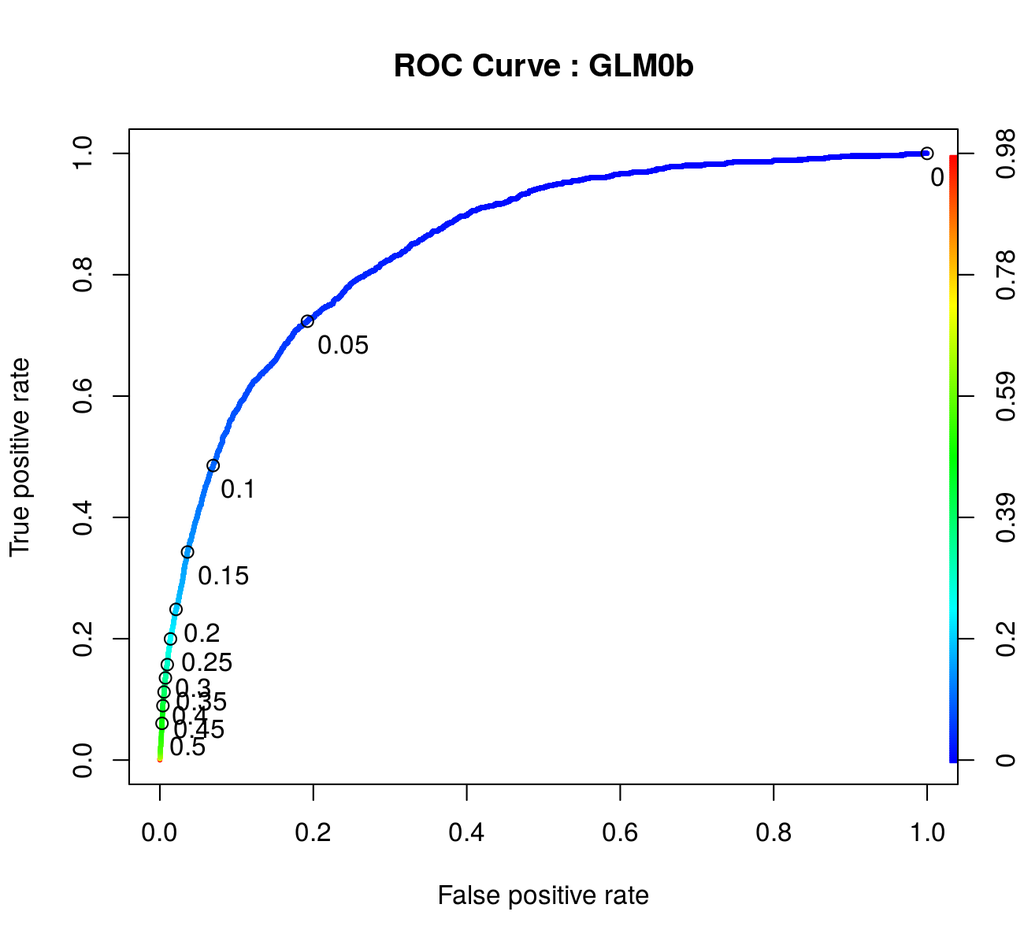

```r
# cutoffs <- seq(0.0, 1.0, by = 0.1)
cutoffs <- seq(0.0, 0.5, by = 0.05)
t.adj <- c(-0.2, 1.7)
str_title <- paste0("ROC Curve : GLM0b")
plot(GLM0b.perf, main = str_title, lwd = 3, colorize = TRUE, print.cutoffs.at = cutoffs, text.adj = t.adj)
```

```r
# perf_vs_threshold <- list()
perf_vs_threshold <- list(AUC = GLM0b.AUC)
i <- 1
for( threshold in seq(0.05, 0.4, by = 0.05)) {
    i <- i + 1
    this_model <- GLM0b.model
    this_test_data <- GLM0b.test
    this_test_predict <- predict(this_model, type = "response", newdata = this_test_data)

    perf_vs_threshold[[i]] <- prepare_cmat_performance(predicted = this_test_predict,
                                                       threshold = threshold,
                                                       truth = this_test_data$Call_Flag)
    names(perf_vs_threshold)[i] <- paste0("thr_", sprintf("%4.2f", threshold))
    if( i == 2 ) {
        perf_vs_threshold.table <- print_cmat_performance(perf_vs_threshold[[i]], errors = FALSE, extended = flag_ext, direction = "h")
    } else {
        perf_vs_threshold.table <- rbind(perf_vs_threshold.table,
                                         print_cmat_performance(perf_vs_threshold[[i]], errors = FALSE, extended = flag_ext, direction = "h"))
    }
    perf_vs_threshold[[i]]$AUC <- GLM0b.AUC
}
GLM0b.perf_vs_threshold <- perf_vs_threshold
GLM0b.perf_vs_threshold$table <- perf_vs_threshold.table
GLM0b.perf_vs_threshold$table$Threshold <- sprintf("**%.2f**", GLM0b.perf_vs_threshold$table$Threshold)
kable(GLM0b.perf_vs_threshold$table, digits = 3, align = "c", caption = "GLM0b Performance Measures vs. Threshold for Classification")
```

GLM0b Performance Measures vs. Threshold for Classification

| Threshold | Accuracy | Sensitivity | Specificity | Precision | NPV | F1 Score |
| --- | --- | --- | --- | --- | --- | --- |
| **0.05** | 0.805 | 0.723 | 0.808 | 0.125 | 0.987 | 0.213 |
| **0.10** | 0.914 | 0.486 | 0.931 | 0.210 | 0.979 | 0.293 |
| **0.15** | 0.941 | 0.343 | 0.964 | 0.265 | 0.975 | 0.299 |
| **0.20** | 0.952 | 0.248 | 0.979 | 0.309 | 0.972 | 0.276 |
| **0.25** | 0.957 | 0.200 | 0.986 | 0.354 | 0.970 | 0.255 |
| **0.30** | 0.960 | 0.157 | 0.990 | 0.382 | 0.969 | 0.223 |
| **0.35** | 0.961 | 0.135 | 0.993 | 0.413 | 0.968 | 0.203 |
| **0.40** | 0.962 | 0.112 | 0.995 | 0.439 | 0.967 | 0.179 |

# Logistic Regression w/ `data1`

We fit `data1` using R’s `glm()` function. The summary is shown below.

```r
GLM1.train <- data1.train
GLM1.test <-  data1.test

GLM1.model <- glm(Call_Flag ~ . , data = GLM1.train, family = "binomial")
```

```r
summary(GLM1.model)
#
# Call:
# glm(formula = Call_Flag ~ ., family = "binomial", data = GLM1.train)
#
# Deviance Residuals:
#     Min       1Q   Median       3Q      Max
# -1.8624  -0.2855  -0.1407  -0.0922   4.6693
#
# Coefficients:
#                        Estimate Std. Error z value Pr(>|z|)
# (Intercept)           -2.395019   0.137472 -17.422  < 2e-16 ***
# CustomerSegment2      -0.001805   0.048351  -0.037 0.970228
# CustomerSegment3      -0.026918   0.087922  -0.306 0.759483
# CustomerSegmentNONE   -0.784947   0.135776  -5.781 7.42e-09 ***
# Tenure                -0.024667   0.003163  -7.798 6.28e-15 ***
# Age                    0.006864   0.001567   4.380 1.19e-05 ***
# MART_STATUSMS_1       -0.071467   0.097743  -0.731 0.464672
# MART_STATUSMS_2       -0.114427   0.095474  -1.199 0.230716
# MART_STATUSMS_3       -0.107949   0.104499  -1.033 0.301599
# MART_STATUSMS_4        0.041449   0.114427   0.362 0.717178
# GENDERM                0.072831   0.039071   1.864 0.062314 .
# CHANNEL1_3M            0.697623   0.057583  12.115  < 2e-16 ***
# CHANNEL2_3M            0.518109   0.035376  14.646  < 2e-16 ***
# CHANNEL3_3M           -0.039547   0.048060  -0.823 0.410578
# CHANNEL4_3M            1.419993   0.034783  40.824  < 2e-16 ***
# CHANNEL5_3M           -0.405514   0.078649  -5.156 2.52e-07 ***
# METHOD1_3M             0.010704   0.018716   0.572 0.567385
# PAYMENTS_3M           -0.824999   0.034346 -24.020  < 2e-16 ***
# RECENT_PAYMENT        -1.054330   0.090055 -11.708  < 2e-16 ***
# NOT_DI_3M              0.977030   0.171384   5.701 1.19e-08 ***
# NOT_DI_6M             -0.460525   0.135822  -3.391 0.000697 ***
# EVENT2_90_SUM         -0.325121   0.042199  -7.704 1.31e-14 ***
# LOGINS                -0.141292   0.024384  -5.794 6.85e-09 ***
# POLICYPURCHASECHANNEL -0.756459   0.078682  -9.614  < 2e-16 ***
# ---
# Signif. codes:  0 '***' 0.001 '**' 0.01 '*' 0.05 '.' 0.1 ' ' 1
#
# (Dispersion parameter for binomial family taken to be 1)
#
#     Null deviance: 28386  on 90493  degrees of freedom
# Residual deviance: 22712  on 90470  degrees of freedom
# AIC: 22760
#
# Number of Fisher Scoring iterations: 8
```

### Prediction on Test set

Setting a **threshold** on the response at **0.2**

```r
GLM1.test.predict <- predict(GLM1.model, type = "response", newdata = GLM1.test)

GLM1.test.performance <- prepare_cmat_performance(predicted = GLM1.test.predict > GLM1.threshold, truth = GLM1.test$Call_Flag)
GLM1.test.cmat <- GLM1.test.performance$cmatrix
GLM1.test.accuracy <- GLM1.test.performance$accuracy

GLM1.ROCR_pred_test <- prediction(GLM1.test.predict, GLM1.test$Call_Flag)
GLM1.perf <- performance(GLM1.ROCR_pred_test, "tpr", "fpr")
GLM1.AUC <- as.numeric(performance(GLM1.ROCR_pred_test, "auc")@y.values)

GLM1.test.performance$AUC <- GLM1.AUC
```

- With a threshold at **0.2** the *out-of-sample* confusion matrix for this fit and train/test sets is:

GLM1 Confusion Matrix (threshold = 0.2)

|  | 0 | 1 |
| --- | --- | --- |
| FALSE | 36732 | 1100 |
| TRUE | 634 | 317 |

The **Area Under the Curve** (**AUC**) for this model on the test data is **0.8343**, which means that our model can differentiate between a randomly selected *retained* and *non-retained* user about **83.43%** of the times.

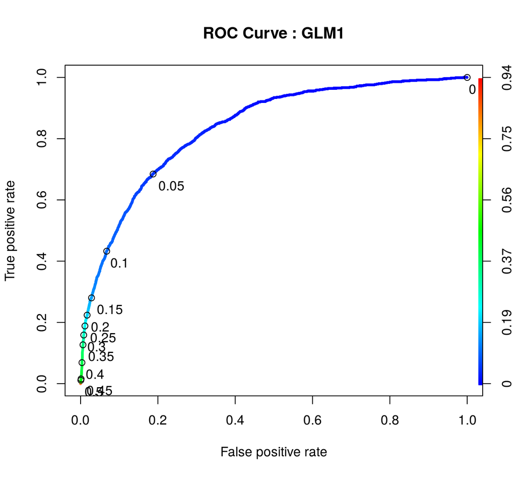

```r
# cutoffs <- seq(0.0, 1.0, by = 0.1)
cutoffs <- seq(0.0, 0.5, by = 0.05)
t.adj <- c(-0.2, 1.7)
str_title <- paste0("ROC Curve : GLM1")
plot(GLM1.perf, main = str_title, lwd = 3, colorize = TRUE, print.cutoffs.at = cutoffs, text.adj = t.adj)
```

```r
# perf_vs_threshold <- list()
perf_vs_threshold <- list(AUC = GLM1.AUC)
i <- 1
for( threshold in seq(0.05, 0.4, by = 0.05)) {
    i <- i + 1
    this_model <- GLM1.model
    this_test_data <- GLM1.test
    this_test_predict <- predict(this_model, type = "response", newdata = this_test_data)

    perf_vs_threshold[[i]] <- prepare_cmat_performance(predicted = this_test_predict,
                                                       threshold = threshold,
                                                       truth = this_test_data$Call_Flag)
    names(perf_vs_threshold)[i] <- paste0("thr_", sprintf("%4.2f", threshold))
    if( i == 2 ) {
        perf_vs_threshold.table <- print_cmat_performance(perf_vs_threshold[[i]], errors = FALSE, extended = flag_ext, direction = "h")
    } else {
        perf_vs_threshold.table <- rbind(perf_vs_threshold.table,
                                         print_cmat_performance(perf_vs_threshold[[i]], errors = FALSE, extended = flag_ext, direction = "h"))
    }
    perf_vs_threshold[[i]]$AUC <- GLM1.AUC
}
GLM1.perf_vs_threshold <- perf_vs_threshold
GLM1.perf_vs_threshold$table <- perf_vs_threshold.table
GLM1.perf_vs_threshold$table$Threshold <- sprintf("**%.2f**", GLM1.perf_vs_threshold$table$Threshold)
kable(GLM1.perf_vs_threshold$table, digits = 3, align = "c", caption = "GLM1 Performance Measures vs. Threshold for Classification")
```

GLM1 Performance Measures vs. Threshold for Classification

| Threshold | Accuracy | Sensitivity | Specificity | Precision | NPV | F1 Score |
| --- | --- | --- | --- | --- | --- | --- |
| **0.05** | 0.808 | 0.685 | 0.812 | 0.122 | 0.985 | 0.206 |
| **0.10** | 0.914 | 0.433 | 0.932 | 0.195 | 0.977 | 0.269 |
| **0.15** | 0.946 | 0.280 | 0.972 | 0.273 | 0.973 | 0.276 |
| **0.20** | 0.955 | 0.224 | 0.983 | 0.333 | 0.971 | 0.268 |
| **0.25** | 0.959 | 0.188 | 0.989 | 0.388 | 0.970 | 0.254 |
| **0.30** | 0.961 | 0.159 | 0.992 | 0.425 | 0.969 | 0.231 |
| **0.35** | 0.962 | 0.126 | 0.994 | 0.433 | 0.968 | 0.196 |
| **0.40** | 0.962 | 0.068 | 0.996 | 0.418 | 0.966 | 0.118 |

# Logistic Regression w/ `data2`

```r
GLM2.train <- data2.train
GLM2.test <-  data2.test

GLM2.model <- glm(Call_Flag ~ . , data = GLM2.train, family = "binomial")
```

```r
summary(GLM2.model)
#
# Call:
# glm(formula = Call_Flag ~ ., family = "binomial", data = GLM2.train)
#
# Deviance Residuals:
#     Min       1Q   Median       3Q      Max
# -2.6698  -0.2763  -0.1404  -0.0853   4.5054
#
# Coefficients:
#                        Estimate Std. Error z value Pr(>|z|)
# (Intercept)           -2.052984   0.141620 -14.496  < 2e-16 ***
# CustomerSegment2      -0.058134   0.048683  -1.194   0.2324
# CustomerSegment3      -0.126075   0.090712  -1.390   0.1646
# CustomerSegmentNONE   -0.777691   0.127376  -6.105 1.02e-09 ***
# Tenure                -0.017931   0.003192  -5.617 1.94e-08 ***
# Age                    0.004957   0.001596   3.105   0.0019 **
# MART_STATUSMS_1       -0.136844   0.099221  -1.379   0.1678
# MART_STATUSMS_2       -0.128764   0.096775  -1.331   0.1833
# MART_STATUSMS_3       -0.135571   0.105988  -1.279   0.2009
# MART_STATUSMS_4        0.026054   0.115541   0.225   0.8216
# GENDERM                0.084080   0.039608   2.123   0.0338 *
# CHANNEL1_6M            0.454811   0.056696   8.022 1.04e-15 ***
# CHANNEL2_6M            0.372960   0.042901   8.693  < 2e-16 ***
# CHANNEL3_6M            0.137389   0.058677   2.341   0.0192 *
# CHANNEL4_6M            0.865981   0.040624  21.317  < 2e-16 ***
# CHANNEL5_6M           -0.138312   0.088539  -1.562   0.1183
# METHOD1_6M             0.045443   0.029045   1.565   0.1177
# PAYMENTS_6M           -0.554347   0.039668 -13.975  < 2e-16 ***
# CHANNEL1_3M           -0.031197   0.103220  -0.302   0.7625
# CHANNEL2_3M           -0.090882   0.077831  -1.168   0.2429
# CHANNEL3_3M           -0.177801   0.108223  -1.643   0.1004
# CHANNEL4_3M            0.037344   0.072101   0.518   0.6045
# CHANNEL5_3M           -0.027496   0.163335  -0.168   0.8663
# METHOD1_3M            -0.097339   0.054913  -1.773   0.0763 .
# PAYMENTS_3M            0.004137   0.067561   0.061   0.9512
# RECENT_PAYMENT        -1.100814   0.091720 -12.002  < 2e-16 ***
# NOT_DI_3M              0.846276   0.168545   5.021 5.14e-07 ***
# NOT_DI_6M             -0.252005   0.148793  -1.694   0.0903 .
# EVENT2_90_SUM         -0.279579   0.041504  -6.736 1.63e-11 ***
# LOGINS                -0.089597   0.022239  -4.029 5.61e-05 ***
# POLICYPURCHASECHANNEL -0.556380   0.075585  -7.361 1.83e-13 ***
# ---
# Signif. codes:  0 '***' 0.001 '**' 0.01 '*' 0.05 '.' 0.1 ' ' 1
#
# (Dispersion parameter for binomial family taken to be 1)
#
#     Null deviance: 28386  on 90493  degrees of freedom
# Residual deviance: 22071  on 90463  degrees of freedom
# AIC: 22133
#
# Number of Fisher Scoring iterations: 8
```

### Prediction on Test set

Setting a **threshold** on the response at **0.2**

```r
GLM2.test.predict <- predict(GLM2.model, type = "response", newdata = GLM2.test)

GLM2.test.performance <- prepare_cmat_performance(predicted = GLM2.test.predict > GLM2.threshold, truth = GLM2.test$Call_Flag)
GLM2.test.cmat <- GLM2.test.performance$cmatrix
GLM2.test.accuracy <- GLM2.test.performance$accuracy

GLM2.ROCR_pred_test <- prediction(GLM2.test.predict, GLM2.test$Call_Flag)
GLM2.perf <- performance(GLM2.ROCR_pred_test, "tpr", "fpr")
GLM2.AUC <- as.numeric(performance(GLM2.ROCR_pred_test, "auc")@y.values)

GLM2.test.performance$AUC <- GLM2.AUC
```

- With a threshold at **0.2** the *out-of-sample* confusion matrix for this fit and train/test sets is:

GLM2 Confusion Matrix (threshold = 0.2)

|  | 0 | 1 |
| --- | --- | --- |
| FALSE | 36697 | 1061 |
| TRUE | 669 | 356 |

The AUC of this model is **0.8552**, *i.e.* it can differentiate between a randomly selected *retained* and *non-retained* user about **85.52%** of the times.

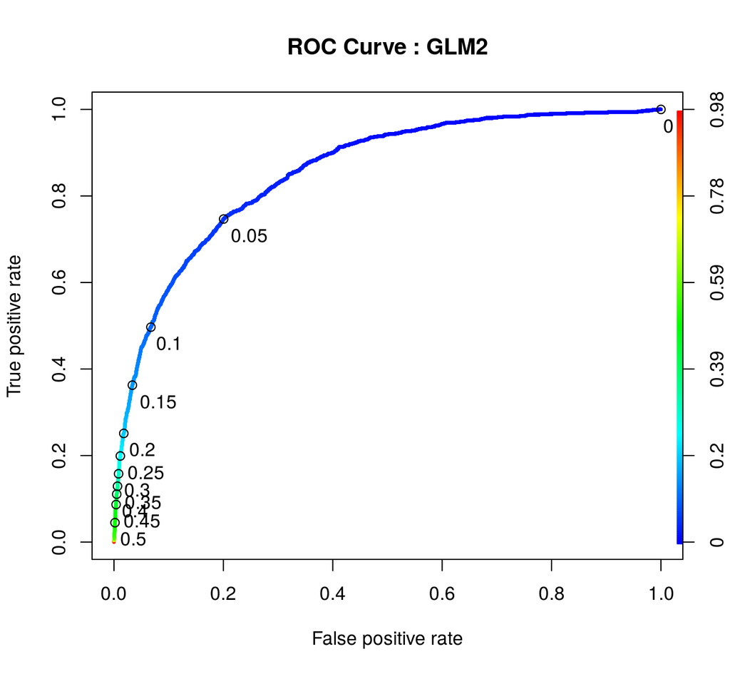

```r
# cutoffs <- seq(0.0, 1.0, by = 0.1)
cutoffs <- seq(0.0, 0.5, by = 0.05)
t.adj <- c(-0.2, 1.7)
str_title <- paste0("ROC Curve : GLM2")
plot(GLM2.perf, main = str_title, lwd = 3, colorize = TRUE, print.cutoffs.at = cutoffs, text.adj = t.adj)
```

```r
# perf_vs_threshold <- list()
perf_vs_threshold <- list(AUC = GLM2.AUC)
i <- 1
for( threshold in seq(0.05, 0.4, by = 0.05)) {
    i <- i + 1
    this_model <- GLM2.model
    this_test_data <- GLM2.test
    this_test_predict <- predict(this_model, type = "response", newdata = this_test_data)

    perf_vs_threshold[[i]] <- prepare_cmat_performance(predicted = this_test_predict,
                                                       threshold = threshold,
                                                       truth = this_test_data$Call_Flag)
    names(perf_vs_threshold)[i] <- paste0("thr_", sprintf("%4.2f", threshold))
    if( i == 2 ) {
        perf_vs_threshold.table <- print_cmat_performance(perf_vs_threshold[[i]], errors = FALSE, extended = flag_ext, direction = "h")
    } else {
        perf_vs_threshold.table <- rbind(perf_vs_threshold.table,
                                         print_cmat_performance(perf_vs_threshold[[i]], errors = FALSE, extended = flag_ext, direction = "h"))
    }
    perf_vs_threshold[[i]]$AUC <- GLM2.AUC
}
GLM2.perf_vs_threshold <- perf_vs_threshold
GLM2.perf_vs_threshold$table <- perf_vs_threshold.table
GLM2.perf_vs_threshold$table$Threshold <- sprintf("**%.2f**", GLM2.perf_vs_threshold$table$Threshold)
kable(GLM2.perf_vs_threshold$table, digits = 3, align = "c", caption = "GLM2 Performance Measures vs. Threshold for Classification")
```

GLM2 Performance Measures vs. Threshold for Classification

| Threshold | Accuracy | Sensitivity | Specificity | Precision | NPV | F1 Score |
| --- | --- | --- | --- | --- | --- | --- |
| **0.05** | 0.798 | 0.747 | 0.800 | 0.124 | 0.988 | 0.212 |
| **0.10** | 0.917 | 0.497 | 0.933 | 0.218 | 0.980 | 0.303 |
| **0.15** | 0.944 | 0.363 | 0.966 | 0.290 | 0.976 | 0.322 |
| **0.20** | 0.955 | 0.251 | 0.982 | 0.347 | 0.972 | 0.292 |
| **0.25** | 0.960 | 0.199 | 0.988 | 0.394 | 0.970 | 0.264 |
| **0.30** | 0.961 | 0.157 | 0.992 | 0.414 | 0.969 | 0.228 |
| **0.35** | 0.962 | 0.129 | 0.994 | 0.431 | 0.968 | 0.199 |
| **0.40** | 0.963 | 0.111 | 0.995 | 0.455 | 0.967 | 0.178 |

# Logistic Regression w/ `data3`

```r
GLM3.train <- data3.train
GLM3.test <-  data3.test

GLM3.model <- glm(Call_Flag ~ . , data = GLM3.train, family = "binomial")
```

```r
summary(GLM3.model)
#
# Call:
# glm(formula = Call_Flag ~ ., family = "binomial", data = GLM3.train)
#
# Deviance Residuals:
#     Min       1Q   Median       3Q      Max
# -2.5346  -0.2673  -0.1361  -0.0817   4.2760
#
# Coefficients:
#                        Estimate Std. Error z value Pr(>|z|)
# (Intercept)           -2.331718   0.304445  -7.659 1.88e-14 ***
# CustomerSegment2      -0.031807   0.049008  -0.649 0.516324
# CustomerSegment3      -0.160325   0.090595  -1.770 0.076778 .
# CustomerSegmentNONE   -0.690185   0.125151  -5.515 3.49e-08 ***
# Tenure                -0.069080   0.021543  -3.207 0.001343 **
# Age                    0.013817   0.011279   1.225 0.220582
# MART_STATUSMS_1       -0.040600   0.101080  -0.402 0.687932
# MART_STATUSMS_2       -0.048920   0.099308  -0.493 0.622291
# MART_STATUSMS_3       -0.053548   0.108765  -0.492 0.622490
# MART_STATUSMS_4        0.097452   0.118550   0.822 0.411056
# GENDERM                0.093711   0.039644   2.364 0.018090 *
# CHANNEL1_6M            0.327987   0.056599   5.795 6.83e-09 ***
# CHANNEL2_6M            0.234948   0.044380   5.294 1.20e-07 ***
# CHANNEL3_6M           -0.003466   0.058970  -0.059 0.953126
# CHANNEL4_6M            0.714920   0.042073  16.992  < 2e-16 ***
# CHANNEL5_6M           -0.246977   0.088672  -2.785 0.005348 **
# METHOD1_6M             0.049237   0.028861   1.706 0.088009 .
# PAYMENTS_6M           -0.463751   0.039864 -11.633  < 2e-16 ***
# CHANNEL1_3M            0.100045   0.101849   0.982 0.325957
# CHANNEL2_3M            0.042281   0.079419   0.532 0.594468
# CHANNEL3_3M           -0.010034   0.107918  -0.093 0.925919
# CHANNEL4_3M            0.203218   0.075001   2.710 0.006738 **
# CHANNEL5_3M            0.037929   0.164008   0.231 0.817109
# METHOD1_3M            -0.097793   0.054148  -1.806 0.070915 .
# PAYMENTS_3M           -0.069978   0.067864  -1.031 0.302467
# RECENT_PAYMENT        -1.133370   0.093166 -12.165  < 2e-16 ***
# NOT_DI_3M              0.987113   0.170899   5.776 7.65e-09 ***
# NOT_DI_6M             -0.599350   0.152954  -3.918 8.91e-05 ***
# EVENT2_90_SUM         -0.324550   0.042081  -7.713 1.23e-14 ***
# LOGINS                -0.090157   0.022194  -4.062 4.86e-05 ***
# POLICYPURCHASECHANNEL -0.574002   0.078328  -7.328 2.33e-13 ***
# Age_grp[25,30)        -0.097759   0.128969  -0.758 0.448448
# Age_grp[30,35)        -0.367413   0.161259  -2.278 0.022703 *
# Age_grp[35,40)        -0.350309   0.201846  -1.736 0.082647 .
# Age_grp[40,45)        -0.297806   0.248582  -1.198 0.230909
# Age_grp[45,50)        -0.340583   0.298971  -1.139 0.254627
# Age_grp[50,55)        -0.412830   0.350382  -1.178 0.238706
# Age_grp[55,60)        -0.464807   0.403222  -1.153 0.249021
# Age_grp[60,65)        -0.479865   0.458102  -1.048 0.294866
# Age_grp[65,70)        -0.529576   0.512161  -1.034 0.301135
# Age_grp[70,75)        -0.589564   0.569301  -1.036 0.300392
# Age_grp[75,100)       -0.591793   0.656633  -0.901 0.367453
# Tenure_grp[2,4)       -0.097729   0.074141  -1.318 0.187452
# Tenure_grp[4,6)        0.049748   0.108799   0.457 0.647496
# Tenure_grp[6,8)        0.028756   0.146371   0.196 0.844251
# Tenure_grp[8,10)       0.122195   0.186840   0.654 0.513108
# Tenure_grp[10,12)      0.308931   0.230367   1.341 0.179907
# Tenure_grp[12,14)      0.563696   0.275139   2.049 0.040484 *
# Tenure_grp[14,16)      0.583997   0.316343   1.846 0.064880 .
# Tenure_grp[16,18)      0.547143   0.364407   1.501 0.133236
# Tenure_grp[18,20)      0.711687   0.416334   1.709 0.087374 .
# Tenure_grp[20,30)      1.044196   0.498575   2.094 0.036228 *
# Tenure_grp[30,40)      1.855354   0.742853   2.498 0.012504 *
# Tenure_grp[40,99)      2.271857   0.888073   2.558 0.010522 *
# Nch_6M                 0.444224   0.043812  10.139  < 2e-16 ***
# Nch_3M                -0.197994   0.056083  -3.530 0.000415 ***
# ---
# Signif. codes:  0 '***' 0.001 '**' 0.01 '*' 0.05 '.' 0.1 ' ' 1
#
# (Dispersion parameter for binomial family taken to be 1)
#
#     Null deviance: 28386  on 90493  degrees of freedom
# Residual deviance: 21936  on 90438  degrees of freedom
# AIC: 22048
#
# Number of Fisher Scoring iterations: 8
```

### Prediction on Test set

Setting a **threshold** on the response at **0.2**

```r
GLM3.test.predict <- predict(GLM3.model, type = "response", newdata = GLM3.test)

GLM3.test.performance <- prepare_cmat_performance(predicted = GLM3.test.predict > GLM3.threshold, truth = GLM3.test$Call_Flag)
GLM3.test.cmat <- GLM3.test.performance$cmatrix
GLM3.test.accuracy <- GLM3.test.performance$accuracy

GLM3.ROCR_pred_test <- prediction(GLM3.test.predict, GLM3.test$Call_Flag)
GLM3.perf <- performance(GLM3.ROCR_pred_test, "tpr", "fpr")
GLM3.AUC <- as.numeric(performance(GLM3.ROCR_pred_test, "auc")@y.values)

GLM3.test.performance$AUC <- GLM3.AUC
```

- With a threshold at **0.2** the *out-of-sample* confusion matrix for this fit and train/test sets is:

GLM3 Confusion Matrix (threshold = 0.2)

|  | 0 | 1 |
| --- | --- | --- |
| FALSE | 36569 | 1000 |
| TRUE | 797 | 417 |

The AUC of this model is **0.8578**, *i.e.* it can differentiate between a randomly selected *retained* and *non-retained* user about **85.78%** of the times.

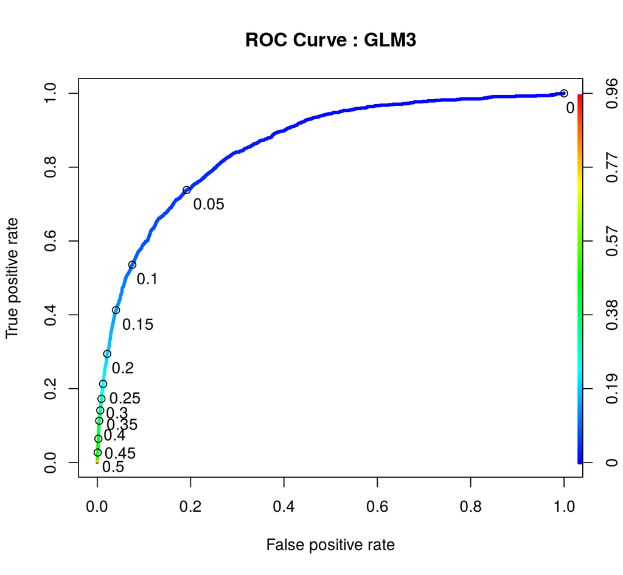

```r
# cutoffs <- seq(0.0, 1.0, by = 0.1)
cutoffs <- seq(0.0, 0.5, by = 0.05)
t.adj <- c(-0.2, 1.7)
str_title <- paste0("ROC Curve : GLM3")
plot(GLM3.perf, main = str_title, lwd = 3, colorize = TRUE, print.cutoffs.at = cutoffs, text.adj = t.adj)
```

```r
# perf_vs_threshold <- list()
perf_vs_threshold <- list(AUC = GLM3.AUC)
i <- 1
for( threshold in seq(0.05, 0.4, by = 0.05)) {
    i <- i + 1
    this_model <- GLM3.model
    this_test_data <- GLM3.test
    this_test_predict <- predict(this_model, type = "response", newdata = this_test_data)

    perf_vs_threshold[[i]] <- prepare_cmat_performance(predicted = this_test_predict,
                                                       threshold = threshold,
                                                       truth = this_test_data$Call_Flag)
    names(perf_vs_threshold)[i] <- paste0("thr_", sprintf("%4.2f", threshold))
    if( i == 2 ) {
        perf_vs_threshold.table <- print_cmat_performance(perf_vs_threshold[[i]], errors = FALSE, extended = flag_ext, direction = "h")
    } else {
        perf_vs_threshold.table <- rbind(perf_vs_threshold.table,
                                         print_cmat_performance(perf_vs_threshold[[i]], errors = FALSE, extended = flag_ext, direction = "h"))
    }
    perf_vs_threshold[[i]]$AUC <- GLM3.AUC
}
GLM3.perf_vs_threshold <- perf_vs_threshold
GLM3.perf_vs_threshold$table <- perf_vs_threshold.table
GLM3.perf_vs_threshold$table$Threshold <- sprintf("**%.2f**", GLM3.perf_vs_threshold$table$Threshold)
kable(GLM3.perf_vs_threshold$table, digits = 3, align = "c", caption = "GLM3 Performance Measures vs. Threshold for Classification")
```

GLM3 Performance Measures vs. Threshold for Classification

| Threshold | Accuracy | Sensitivity | Specificity | Precision | NPV | F1 Score |
| --- | --- | --- | --- | --- | --- | --- |
| **0.05** | 0.806 | 0.738 | 0.808 | 0.127 | 0.988 | 0.217 |
| **0.10** | 0.911 | 0.536 | 0.925 | 0.213 | 0.981 | 0.305 |
| **0.15** | 0.940 | 0.413 | 0.960 | 0.281 | 0.977 | 0.334 |
| **0.20** | 0.954 | 0.294 | 0.979 | 0.343 | 0.973 | 0.317 |
| **0.25** | 0.959 | 0.212 | 0.987 | 0.390 | 0.971 | 0.275 |
| **0.30** | 0.961 | 0.172 | 0.991 | 0.421 | 0.969 | 0.244 |
| **0.35** | 0.962 | 0.141 | 0.994 | 0.456 | 0.968 | 0.216 |
| **0.40** | 0.964 | 0.113 | 0.996 | 0.505 | 0.967 | 0.185 |

# Logistic Regression w/ `data4`

```r
GLM4.train <- data4.train
GLM4.test <-  data4.test

GLM4.model <- glm(Call_Flag ~ . , data = GLM4.train, family = "binomial")
```

```r
summary(GLM4.model)
#
# Call:
# glm(formula = Call_Flag ~ ., family = "binomial", data = GLM4.train)
#
# Deviance Residuals:
#     Min       1Q   Median       3Q      Max
# -2.4322  -0.2724  -0.1421  -0.0923   4.3851
#
# Coefficients:
#                        Estimate Std. Error z value Pr(>|z|)
# (Intercept)           -2.778954   0.300114  -9.260  < 2e-16 ***
# CustomerSegment2       0.021127   0.048717   0.434 0.664535
# CustomerSegment3      -0.062555   0.089808  -0.697 0.486092
# CustomerSegmentNONE   -0.600565   0.126465  -4.749 2.05e-06 ***
# Tenure                -0.072397   0.021073  -3.436 0.000591 ***
# Age                    0.019048   0.011122   1.713 0.086775 .
# MART_STATUSMS_1        0.078172   0.101432   0.771 0.440893
# MART_STATUSMS_2        0.030769   0.099756   0.308 0.757748
# MART_STATUSMS_3        0.038409   0.109040   0.352 0.724653
# MART_STATUSMS_4        0.160379   0.119838   1.338 0.180799
# GENDERM                0.089261   0.039242   2.275 0.022930 *
# CHANNEL1_3M            0.577374   0.060089   9.609  < 2e-16 ***
# CHANNEL2_3M            0.376941   0.041742   9.030  < 2e-16 ***
# CHANNEL3_3M           -0.130016   0.052150  -2.493 0.012663 *
# CHANNEL4_3M            1.287681   0.039281  32.782  < 2e-16 ***
# CHANNEL5_3M           -0.469560   0.079771  -5.886 3.95e-09 ***
# METHOD1_3M            -0.002921   0.019076  -0.153 0.878314
# PAYMENTS_3M           -0.704013   0.035364 -19.908  < 2e-16 ***
# RECENT_PAYMENT        -1.155275   0.094321 -12.248  < 2e-16 ***
# NOT_DI_3M              1.250707   0.174841   7.153 8.47e-13 ***
# NOT_DI_6M             -0.950621   0.139977  -6.791 1.11e-11 ***
# EVENT2_90_SUM         -0.358604   0.042970  -8.345  < 2e-16 ***
# LOGINS                -0.148258   0.025360  -5.846 5.03e-09 ***
# POLICYPURCHASECHANNEL -0.666462   0.078166  -8.526  < 2e-16 ***
# Age_grp[25,30)        -0.086396   0.127646  -0.677 0.498509
# Age_grp[30,35)        -0.430154   0.160595  -2.679 0.007395 **
# Age_grp[35,40)        -0.451374   0.201273  -2.243 0.024923 *
# Age_grp[40,45)        -0.456924   0.246730  -1.852 0.064038 .
# Age_grp[45,50)        -0.490853   0.296501  -1.655 0.097826 .
# Age_grp[50,55)        -0.487966   0.346865  -1.407 0.159490
# Age_grp[55,60)        -0.629599   0.399476  -1.576 0.115012
# Age_grp[60,65)        -0.774073   0.453879  -1.705 0.088108 .
# Age_grp[65,70)        -0.783724   0.506819  -1.546 0.122018
# Age_grp[70,75)        -0.833627   0.563356  -1.480 0.138940
# Age_grp[75,100)       -0.701481   0.647730  -1.083 0.278816
# Tenure_grp[2,4)       -0.019019   0.072669  -0.262 0.793532
# Tenure_grp[4,6)        0.113845   0.106287   1.071 0.284119
# Tenure_grp[6,8)       -0.053859   0.144204  -0.373 0.708781
# Tenure_grp[8,10)      -0.008335   0.183764  -0.045 0.963822
# Tenure_grp[10,12)      0.234648   0.225577   1.040 0.298241
# Tenure_grp[12,14)      0.314025   0.272143   1.154 0.248542
# Tenure_grp[14,16)      0.581583   0.308762   1.884 0.059620 .
# Tenure_grp[16,18)      0.457870   0.356961   1.283 0.199600
# Tenure_grp[18,20)      0.756013   0.407182   1.857 0.063354 .
# Tenure_grp[20,30)      1.082364   0.486805   2.223 0.026189 *
# Tenure_grp[30,40)      1.723908   0.726860   2.372 0.017705 *
# Tenure_grp[40,99)      2.243612   0.869169   2.581 0.009842 **
# Nch_6M                 0.488935   0.039663  12.327  < 2e-16 ***
# Nch_3M                -0.254052   0.054714  -4.643 3.43e-06 ***
# ---
# Signif. codes:  0 '***' 0.001 '**' 0.01 '*' 0.05 '.' 0.1 ' ' 1
#
# (Dispersion parameter for binomial family taken to be 1)
#
#     Null deviance: 28386  on 90493  degrees of freedom
# Residual deviance: 22479  on 90445  degrees of freedom
# AIC: 22577
#
# Number of Fisher Scoring iterations: 8
```

### Prediction on Test set

Setting a **threshold** on the response at **0.2**

```r
GLM4.test.predict <- predict(GLM4.model, type = "response", newdata = GLM4.test)

GLM4.test.performance <- prepare_cmat_performance(predicted = GLM4.test.predict > GLM4.threshold, truth = GLM4.test$Call_Flag)
GLM4.test.cmat <- GLM4.test.performance$cmatrix
GLM4.test.accuracy <- GLM4.test.performance$accuracy

GLM4.ROCR_pred_test <- prediction(GLM4.test.predict, GLM4.test$Call_Flag)
GLM4.perf <- performance(GLM4.ROCR_pred_test, "tpr", "fpr")
GLM4.AUC <- as.numeric(performance(GLM4.ROCR_pred_test, "auc")@y.values)

GLM4.test.performance$AUC <- GLM4.AUC
```

- With a threshold at **0.2** the *out-of-sample* confusion matrix for this fit and train/test sets is:

GLM4 Confusion Matrix (threshold = 0.2)

|  | 0 | 1 |
| --- | --- | --- |
| FALSE | 36621 | 1090 |
| TRUE | 745 | 327 |

The AUC of this model is **0.8416**, *i.e.* it can differentiate between a randomly selected *retained* and *non-retained* user about **84.16%** of the times.

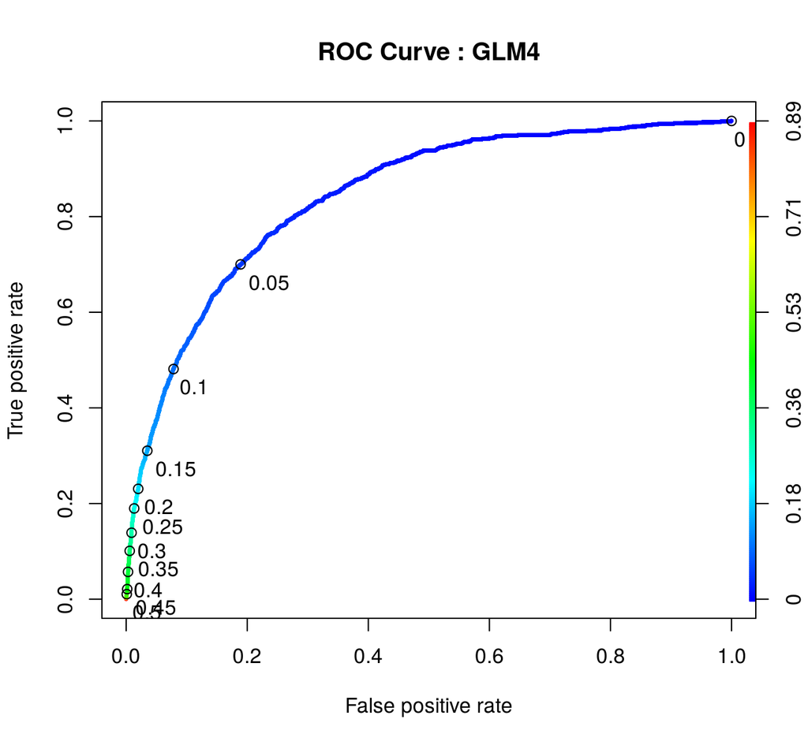

```r
# cutoffs <- seq(0.0, 1.0, by = 0.1)
cutoffs <- seq(0.0, 0.5, by = 0.05)
t.adj <- c(-0.2, 1.7)
str_title <- paste0("ROC Curve : GLM4")
plot(GLM4.perf, main = str_title, lwd = 3, colorize = TRUE, print.cutoffs.at = cutoffs, text.adj = t.adj)
```

```r
# perf_vs_threshold <- list()
perf_vs_threshold <- list(AUC = GLM4.AUC)
i <- 1
for( threshold in seq(0.05, 0.4, by = 0.05)) {
    i <- i + 1
    this_model <- GLM4.model
    this_test_data <- GLM4.test
    this_test_predict <- predict(this_model, type = "response", newdata = this_test_data)

    perf_vs_threshold[[i]] <- prepare_cmat_performance(predicted = this_test_predict,
                                                       threshold = threshold,
                                                       truth = this_test_data$Call_Flag)
    names(perf_vs_threshold)[i] <- paste0("thr_", sprintf("%4.2f", threshold))
    if( i == 2 ) {
        perf_vs_threshold.table <- print_cmat_performance(perf_vs_threshold[[i]], errors = FALSE, extended = flag_ext, direction = "h")
    } else {
        perf_vs_threshold.table <- rbind(perf_vs_threshold.table,
                                         print_cmat_performance(perf_vs_threshold[[i]], errors = FALSE, extended = flag_ext, direction = "h"))
    }
    perf_vs_threshold[[i]]$AUC <- GLM4.AUC
}
GLM4.perf_vs_threshold <- perf_vs_threshold
GLM4.perf_vs_threshold$table <- perf_vs_threshold.table
GLM4.perf_vs_threshold$table$Threshold <- sprintf("**%.2f**", GLM4.perf_vs_threshold$table$Threshold)
kable(GLM4.perf_vs_threshold$table, digits = 3, align = "c", caption = "GLM4 Performance Measures vs. Threshold for Classification")
```

GLM4 Performance Measures vs. Threshold for Classification

| Threshold | Accuracy | Sensitivity | Specificity | Precision | NPV | F1 Score |
| --- | --- | --- | --- | --- | --- | --- |
| **0.05** | 0.807 | 0.700 | 0.811 | 0.123 | 0.986 | 0.210 |
| **0.10** | 0.906 | 0.481 | 0.922 | 0.189 | 0.979 | 0.272 |
| **0.15** | 0.941 | 0.311 | 0.965 | 0.252 | 0.974 | 0.278 |
| **0.20** | 0.953 | 0.231 | 0.980 | 0.305 | 0.971 | 0.263 |
| **0.25** | 0.958 | 0.190 | 0.987 | 0.352 | 0.970 | 0.247 |
| **0.30** | 0.960 | 0.139 | 0.991 | 0.371 | 0.968 | 0.202 |
| **0.35** | 0.961 | 0.101 | 0.994 | 0.394 | 0.967 | 0.161 |
| **0.40** | 0.963 | 0.057 | 0.997 | 0.411 | 0.965 | 0.100 |

# Logistic Regression w/ `data5`

```r
GLM5.train <- data5.train
GLM5.test <-  data5.test

GLM5.model <- glm(Call_Flag ~ . , data = GLM5.train, family = "binomial")
```

```r
summary(GLM5.model)
#
# Call:
# glm(formula = Call_Flag ~ ., family = "binomial", data = GLM5.train)
#
# Deviance Residuals:
#     Min       1Q   Median       3Q      Max
# -2.1168  -0.2770  -0.1403  -0.0850   4.3140
#
# Coefficients:
#                        Estimate Std. Error z value Pr(>|z|)
# (Intercept)           -2.043076   0.138999 -14.698  < 2e-16 ***
# CustomerSegment2      -0.003744   0.048251  -0.078   0.9381
# CustomerSegment3      -0.135771   0.091758  -1.480   0.1390
# CustomerSegmentNONE   -0.812813   0.133232  -6.101 1.06e-09 ***
# Tenure                -0.012880   0.003085  -4.175 2.98e-05 ***
# Age                    0.004859   0.001587   3.062   0.0022 **
# MART_STATUSMS_1       -0.181290   0.095899  -1.890   0.0587 .
# MART_STATUSMS_2       -0.197447   0.093510  -2.111   0.0347 *
# MART_STATUSMS_3       -0.197083   0.102606  -1.921   0.0548 .
# MART_STATUSMS_4       -0.181498   0.115455  -1.572   0.1159
# GENDERM                0.075518   0.039476   1.913   0.0557 .
# CHANNEL1_6M            0.384039   0.055564   6.912 4.79e-12 ***
# CHANNEL2_6M            0.333966   0.041497   8.048 8.42e-16 ***
# CHANNEL3_6M            0.125708   0.056939   2.208   0.0273 *
# CHANNEL4_6M            0.811802   0.039487  20.559  < 2e-16 ***
# CHANNEL5_6M           -0.137580   0.087834  -1.566   0.1173
# METHOD1_6M             0.067319   0.028946   2.326   0.0200 *
# PAYMENTS_6M           -0.516420   0.038536 -13.401  < 2e-16 ***
# CHANNEL1_3M            0.085424   0.102791   0.831   0.4060
# CHANNEL2_3M           -0.035340   0.076786  -0.460   0.6453
# CHANNEL3_3M           -0.160287   0.106881  -1.500   0.1337
# CHANNEL4_3M            0.116987   0.071494   1.636   0.1018
# CHANNEL5_3M           -0.047260   0.164524  -0.287   0.7739
# METHOD1_3M            -0.102310   0.054942  -1.862   0.0626 .
# PAYMENTS_3M           -0.059134   0.066784  -0.885   0.3759
# RECENT_PAYMENT        -1.148068   0.094972 -12.088  < 2e-16 ***
# NOT_DI_3M              0.743763   0.172767   4.305 1.67e-05 ***
# NOT_DI_6M             -0.144850   0.150769  -0.961   0.3367
# EVENT2_90_SUM         -0.305335   0.041580  -7.343 2.08e-13 ***
# LOGINS                -0.128918   0.025151  -5.126 2.96e-07 ***
# POLICYPURCHASECHANNEL -0.596018   0.077663  -7.674 1.66e-14 ***
# ---
# Signif. codes:  0 '***' 0.001 '**' 0.01 '*' 0.05 '.' 0.1 ' ' 1
#
# (Dispersion parameter for binomial family taken to be 1)
#
#     Null deviance: 28604  on 91059  degrees of freedom
# Residual deviance: 22259  on 91029  degrees of freedom
# AIC: 22321
#
# Number of Fisher Scoring iterations: 8
```

### Prediction on Test set

Setting a **threshold** on the response at **0.2**

```r
GLM5.test.predict <- predict(GLM5.model, type = "response", newdata = GLM5.test)

GLM5.test.performance <- prepare_cmat_performance(predicted = GLM5.test.predict > GLM5.threshold, truth = GLM5.test$Call_Flag)
GLM5.test.cmat <- GLM5.test.performance$cmatrix
GLM5.test.accuracy <- GLM5.test.performance$accuracy

GLM5.ROCR_pred_test <- prediction(GLM5.test.predict, GLM5.test$Call_Flag)
GLM5.perf <- performance(GLM5.ROCR_pred_test, "tpr", "fpr")
GLM5.AUC <- as.numeric(performance(GLM5.ROCR_pred_test, "auc")@y.values)

GLM5.test.performance$AUC <- GLM5.AUC
```

- With a threshold at **0.2** the *out-of-sample* confusion matrix for this fit and train/test sets is:

GLM5 Confusion Matrix (threshold = 0.2)

|  | 0 | 1 |
| --- | --- | --- |
| FALSE | 36920 | 1073 |
| TRUE | 677 | 356 |

The AUC of this model is **0.8505**, *i.e.* it can differentiate between a randomly selected *retained* and *non-retained* user about **85.05%** of the times.

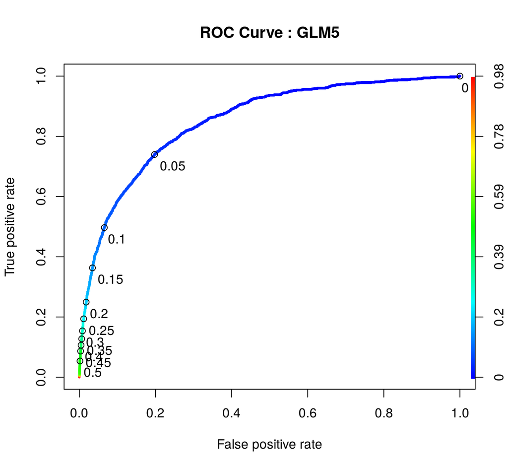

```r
# cutoffs <- seq(0.0, 1.0, by = 0.1)
cutoffs <- seq(0.0, 0.5, by = 0.05)
t.adj <- c(-0.2, 1.7)
str_title <- paste0("ROC Curve : GLM5")
plot(GLM5.perf, main = str_title, lwd = 3, colorize = TRUE, print.cutoffs.at = cutoffs, text.adj = t.adj)
```

```r
# perf_vs_threshold <- list()
perf_vs_threshold <- list(AUC = GLM5.AUC)
i <- 1
for( threshold in seq(0.05, 0.4, by = 0.05)) {
    i <- i + 1
    this_model <- GLM5.model
    this_test_data <- GLM5.test
    this_test_predict <- predict(this_model, type = "response", newdata = this_test_data)

    perf_vs_threshold[[i]] <- prepare_cmat_performance(predicted = this_test_predict,
                                                       threshold = threshold,
                                                       truth = this_test_data$Call_Flag)
    names(perf_vs_threshold)[i] <- paste0("thr_", sprintf("%4.2f", threshold))
    if( i == 2 ) {
        perf_vs_threshold.table <- print_cmat_performance(perf_vs_threshold[[i]], errors = FALSE, extended = flag_ext, direction = "h")
    } else {
        perf_vs_threshold.table <- rbind(perf_vs_threshold.table,
                                         print_cmat_performance(perf_vs_threshold[[i]], errors = FALSE, extended = flag_ext, direction = "h"))
    }
    perf_vs_threshold[[i]]$AUC <- GLM5.AUC
}
GLM5.perf_vs_threshold <- perf_vs_threshold
GLM5.perf_vs_threshold$table <- perf_vs_threshold.table
GLM5.perf_vs_threshold$table$Threshold <- sprintf("**%.2f**", GLM5.perf_vs_threshold$table$Threshold)
kable(GLM5.perf_vs_threshold$table, digits = 3, align = "c", caption = "GLM5 Performance Measures vs. Threshold for Classification")
```

GLM5 Performance Measures vs. Threshold for Classification

| Threshold | Accuracy | Sensitivity | Specificity | Precision | NPV | F1 Score |
| --- | --- | --- | --- | --- | --- | --- |
| **0.05** | 0.800 | 0.740 | 0.802 | 0.124 | 0.988 | 0.213 |
| **0.10** | 0.918 | 0.497 | 0.934 | 0.223 | 0.980 | 0.308 |
| **0.15** | 0.943 | 0.363 | 0.966 | 0.286 | 0.976 | 0.320 |
| **0.20** | 0.955 | 0.249 | 0.982 | 0.345 | 0.972 | 0.289 |
| **0.25** | 0.960 | 0.194 | 0.989 | 0.393 | 0.970 | 0.260 |
| **0.30** | 0.961 | 0.153 | 0.992 | 0.414 | 0.969 | 0.224 |
| **0.35** | 0.962 | 0.127 | 0.994 | 0.435 | 0.968 | 0.197 |
| **0.40** | 0.963 | 0.106 | 0.995 | 0.465 | 0.967 | 0.173 |

# SUMMARY of ALL GLM MODELS

### Performance Measures

Summary of Performance Measures (threshold = 0.1)

|  | Metric | GLM0a | GLM0b | GLM1 | GLM2 | GLM3 | GLM4 | GLM5 |
| --- | --- | --- | --- | --- | --- | --- | --- | --- |
| 1 | AUC | 0.851 | 0.851 | 0.834 | 0.855 | 0.858 | 0.842 | 0.851 |
| 3 | Accuracy | 0.913 | 0.914 | 0.914 | 0.917 | 0.911 | 0.906 | 0.918 |
| 4 | Sensitivity | 0.498 | 0.486 | 0.433 | 0.497 | 0.536 | 0.481 | 0.497 |
| 5 | Specificity | 0.929 | 0.931 | 0.932 | 0.933 | 0.925 | 0.922 | 0.934 |
| 6 | Precision | 0.210 | 0.210 | 0.195 | 0.218 | 0.213 | 0.189 | 0.223 |
| 7 | NPV | 0.980 | 0.979 | 0.977 | 0.980 | 0.981 | 0.979 | 0.980 |
| 8 | F1 Score | 0.296 | 0.293 | 0.269 | 0.303 | 0.305 | 0.272 | 0.308 |

Summary of Performance Measures (threshold = 0.2)

|  | Metric | GLM0a | GLM0b | GLM1 | GLM2 | GLM3 | GLM4 | GLM5 |
| --- | --- | --- | --- | --- | --- | --- | --- | --- |
| 1 | AUC | 0.851 | 0.851 | 0.834 | 0.855 | 0.858 | 0.842 | 0.851 |
| 3 | Accuracy | 0.952 | 0.952 | 0.955 | 0.955 | 0.954 | 0.953 | 0.955 |
| 4 | Sensitivity | 0.253 | 0.248 | 0.224 | 0.251 | 0.294 | 0.231 | 0.249 |
| 5 | Specificity | 0.978 | 0.979 | 0.983 | 0.982 | 0.979 | 0.980 | 0.982 |
| 6 | Precision | 0.307 | 0.309 | 0.333 | 0.347 | 0.343 | 0.305 | 0.345 |
| 7 | NPV | 0.972 | 0.972 | 0.971 | 0.972 | 0.973 | 0.971 | 0.972 |
| 8 | F1 Score | 0.277 | 0.276 | 0.268 | 0.292 | 0.317 | 0.263 | 0.289 |

# APPENDIX

## R Session Info

```r
sessionInfo()
# R version 3.1.3 (2015-03-09)
# Platform: x86_64-pc-linux-gnu (64-bit)
# Running under: Ubuntu 14.04.3 LTS
#
# locale:
#  [1] LC_CTYPE=en_US.UTF-8       LC_NUMERIC=C               LC_TIME=en_US.UTF-8
#  [4] LC_COLLATE=C               LC_MONETARY=en_US.UTF-8    LC_MESSAGES=en_US.UTF-8
#  [7] LC_PAPER=en_US.UTF-8       LC_NAME=C                  LC_ADDRESS=C
# [10] LC_TELEPHONE=C             LC_MEASUREMENT=en_US.UTF-8 LC_IDENTIFICATION=C
#
# attached base packages:
# [1] stats     graphics  grDevices utils     datasets  methods   base
#
# other attached packages:
# [1] ROCR_1.0-7      gplots_2.17.0   caTools_1.17.1  gridExtra_2.0.0 scales_0.3.0    ggplot2_1.0.1
# [7] lubridate_1.3.3 dplyr_0.4.2     knitr_1.11
#
# loaded via a namespace (and not attached):
#  [1] DBI_0.3.1          KernSmooth_2.23-14 MASS_7.3-43        R6_2.1.1           Rcpp_0.12.0
#  [6] assertthat_0.1     bitops_1.0-6       colorspace_1.2-6   digest_0.6.8       evaluate_0.7.2
# [11] formatR_1.2        gdata_2.17.0       grid_3.1.3         gtable_0.1.2       gtools_3.5.0
# [16] highr_0.5          htmltools_0.2.6    magrittr_1.5       memoise_0.2.1      munsell_0.4.2
# [21] parallel_3.1.3     plyr_1.8.3         proto_0.3-10       reshape2_1.4.1     rmarkdown_0.7
# [26] stringi_0.5-5      stringr_1.0.0      tools_3.1.3        yaml_2.1.13
```